# R Bootcamp

2018-08-16 04:22:13

## Acknowledgments

- [Psychology Department](http://psych.la.psu.edu)
- [Social, Life, & Engineering Sciences Imaging Center (SLEIC)](http://www.imaging.psu.edu)
- [Child Study Center's Open Data and Developmental Science (ODDS) initiative](http://csc.la.psu.edu/research/collaborative-research-initiatives)

## Agenda

- Welcome and introductions
- Housekeeping
- Schedule
- Aspirations & Philosophy
- The stoRy of R

## Welcome and introductions

- Michael Hallquist
- Rick Gilmore
- Nilam Ram

## Welcome and introductions

- Dan Albohn
- Kayla Brown
- Ben Johnson
- Alicia Vallorani

## Who R You?

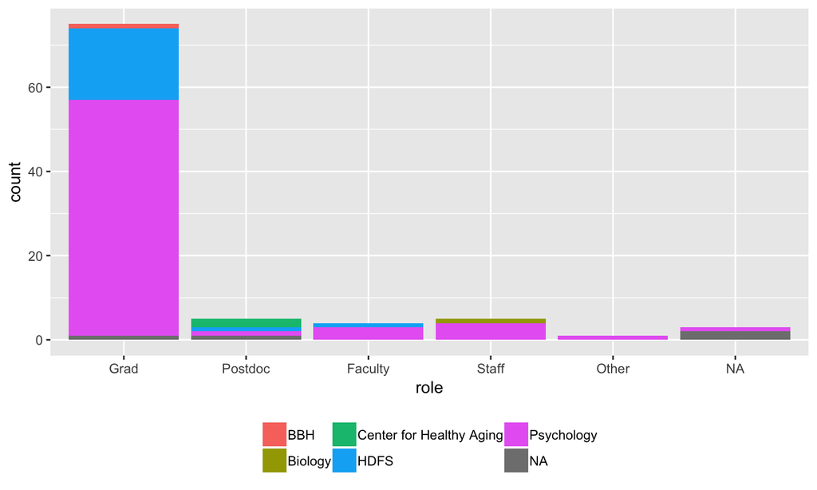

## Housekeeping

- Bootcamp materials on GitHub: https://github.com/psu-psychology/r-bootcamp-2018
- Bootcamp website: http://psu-psychology.github.io/r-bootcamp-2018
- **Survey**: Please complete this anonymous (and light-hearted) [survey](https://docs.google.com/forms/d/1l5OX8PcN_lfVn3ykr_PtHCzhRbWzMbxhqtgILD45zRg/edit) *before lunch*.
- **Sessions are being video recorded**. Last year's is on [Databrary](http://doi.org/10.17910/B7.473)

## Schedule

- **Day 1** (Thursday, August 16, 2018): 104 Keller & 104 Rackley
- **Day 2** (Friday, August 17, 2018): 104 Keller

## Day 1 Schedule

|  | Plenary session, 104 Keller |
| --- | --- |
|  | 09:00 am • Welcome, introductions, & housekeeping |
|  | 09:15 am • Why We R Here |
|  | 09:45 am • Break |

## Day 1 Schedule

|  | Slow-R Track, 104 Keller | Fast-R Track, 104 Rackley |
| --- | --- | --- |
|  | 10:00 am - 12:00pm • RStudio, R console, object classes & data types (Rick Gilmore) | 10:00 am - 12:00pm • Introduction to exploratory factor analysis (Nilam Ram) |

|  | Lunch, Moore 1st floor lobby |
| --- | --- |
|  | 12:00 pm • Lunch (thanks to the Child Study Center (CSC)) |

## Day 1 Schedule

|  | Slow-R Track, 104 Keller | Fast-R Track, 104 Rackley |
| --- | --- | --- |
|  | 1:00 pm - 1:45 pm • Data indexing and subsetting (Rick Gilmore) | 1:00 pm - 2:00 pm • Introduction to structural equation modeling in lavaan (Michael Hallquist) |
|  | 1:45 pm - 3:00 pm • Packages, scripts, & functions (Rick Gilmore) | 02:00 pm - 3:00 pm • Parallel computing, batch processing, and big data in R (Michael Hallquist) |
|  | 03:00 - 03:15 pm • Break | 03:00 pm - 03:15pm • Break |

## Day 1 Schedule

|  | Plenary, 104 Keller |
| --- | --- |
|  | 03:15 pm • R-eproducible Science with R (Rick Gilmore) |
|  | 04:30 pm • End |

## Day 2 Schedule

|  | Plenary |
| --- | --- |
|  | 09:00 am • Welcome back and Q&A |
|  | 09:15 am • Data wrangling & pipelines (primarily tidyverse) |
|  | 10:30 am • Break |
|  | 10:45 am • Data visualization (primarily ggplot2) |
|  | 12:00 pm • Lunch (pizza & drinks thanks to [SLEIC](http://imaging.psu.edu)) |

## Day 2 Schedule

|  | Plenary |
| --- | --- |
|  | 01:00 pm • Core programming skills: loops, apply functions, writing functions |
|  | 02:00 pm • Best practices in R: script management, versioning, modular coding |
|  | 02:45 pm • Break |
|  | 03:00 pm • Basic data analyses in R: correlation, regression, ANOVA, categorical data |
|  | 04:30 pm • End |
|  | 04:45 pm • Optional Happy Hour @ Whisker's |

## Aspirations & Philosophy

- You **can** learn to program
- You **should** learn to program
- R is a good language for learning programming

[figure not shown]

## The storRy of R

[figure not shown]

## The storRy of *our* R

- What is R?
  - A programming language, written by and for statisticians & data scientists
- Why is it called R?
  - TLDR: it's the free, open-source version of a commercial program called S developed in the 1970s at Bell Labs
  - Bell Labs is also the home of C, and the Unix operating system

## The storRy of R

- Features of R
  - Written in C, Fortran, and R
  - 14th most [popular programming language](https://www.tiobe.com/tiobe-index/)
  - Base R (now 3.5.1) + thousands of packages
  - Object-oriented

## Using R

- On your own computer
- In the cloud from your browser
  - https://lxclusterapps.tlt.psu.edu:8787

## Some of ouR own eye-candy

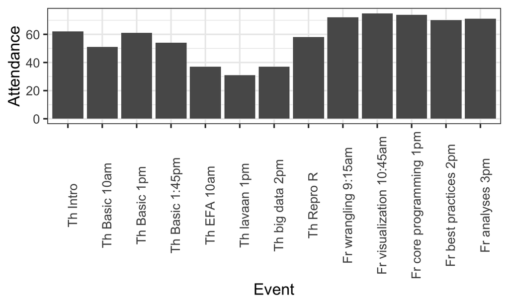

[figure not shown]

github.com/PLAY-behaviorome/

[figure not shown]

[Gilmore, Thomas, & Fesi, 2016](http://dx.doi.org/10.1371/journal.pone.0157911)

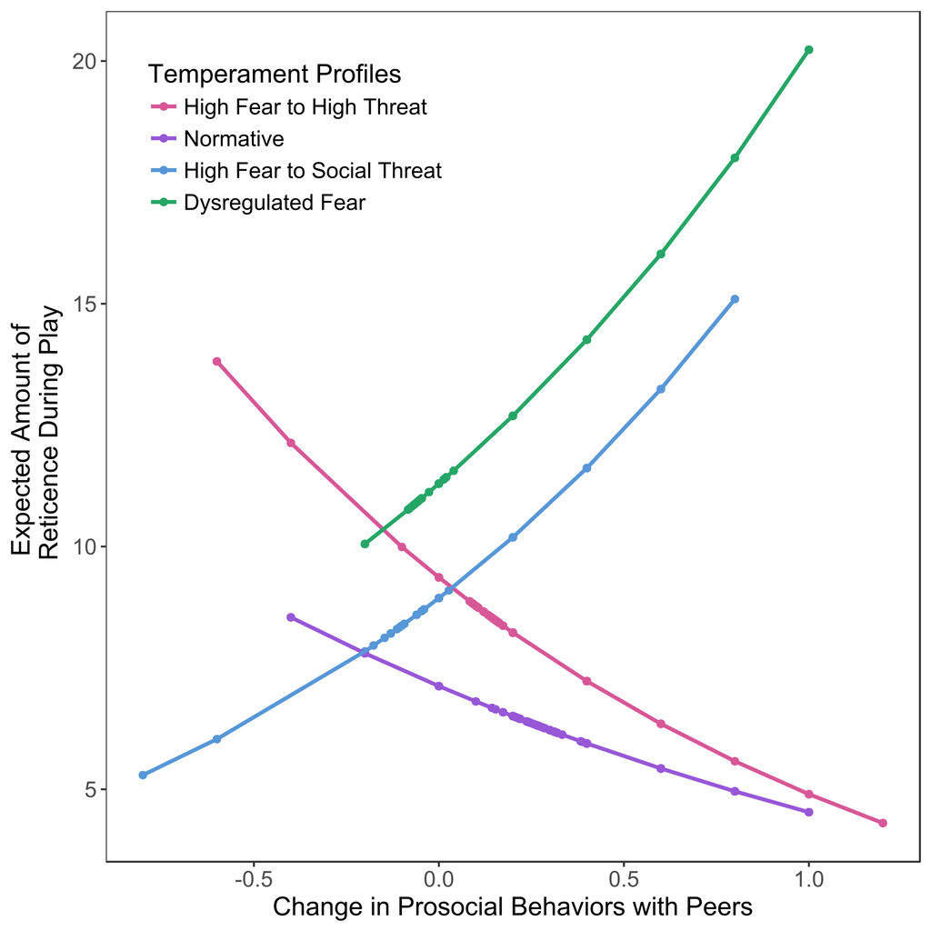

Alicia Vallorani

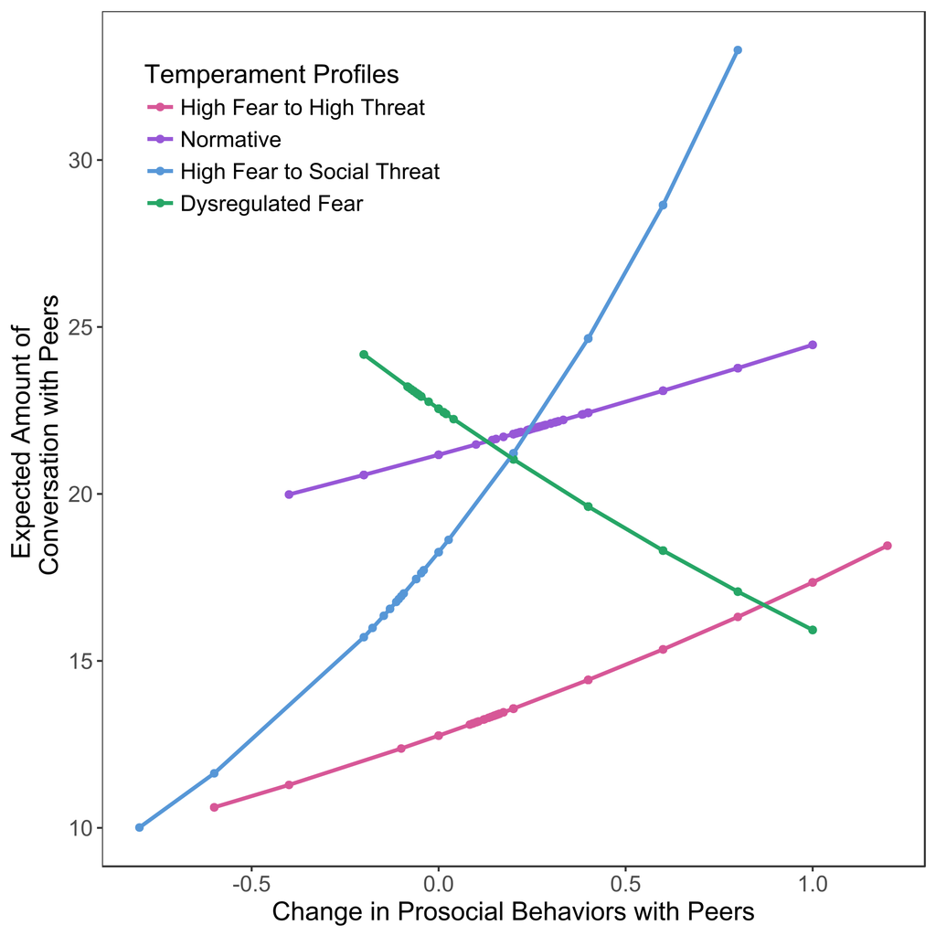

Alicia Vallorani

## Your turn

- Why do you want to learn R?
- If you know some R, what else do you want to learn?
- Complete the [survey!](https://docs.google.com/forms/d/e/1FAIpQLSeGqic9Hrj-XvkESZmu_0t6H02R-U6yzYnRLuX6HDFDp4R39g/viewform?usp=sf_link)
- Testimonials?

## Next steps

- Slow R (stay here in 104 Keller)
- Fast R (104 Rackley Moore)
- Lunch (Moore Building Lobby)